# TempoGap: An method to predicted the recovery status in patients

TeDing Chang, Hamed Moheimani, Das Jishnu, Timothy R. Billiar

2025-11-19

# 1. Introduction

`TempoGap` is an R package designed to quantify the temporal gap between the actual time since disease happened and the biological recovery time inferred from molecular or cellular data. This concept is important in whole period of disease, where biological recovery often lags behind clinical timelines. TempoGap provides a reproducible framework to:

- estimate biological recovery predicted vs. actual recovery time.
- compute the difference between predicted vs. actual recovery time
- identify patients with delayed recovery trajectories.
- support prognostic and monitoring applications in trauma or critical care patients.

This vignette introduces the scientific background, explains the method, and demonstrates typical workflows.

# 2. Scientific Background

Trauma induces strong immune activation followed by dysregulation. However, clinical time since injury does not always match molecular recovery. To address this, we model: - $y$: actual time since injury. - $x$: immune features (genes, proteins, etc.). - $n$: number of samples - $β$: coefficients describing contribution of each feature.

`TempoGap` estimates the immunological recovery time $\hat{y}$ using the least absolute shrinkage and selection operator (LASSO) regression:
$$\hat{\beta}(\lambda)
=
\arg\min_{\beta}
\left[
\frac{1}{2n} \lVert y - X\beta \rVert_{2}^{2}
+ \lambda \lVert \beta \rVert_{1}
\right]$$

Then the temporal gap is calculated as:
$$\text{Gap} = \hat{y} - loess(y)$$
There is the overview of `TempoGap` algorithm:

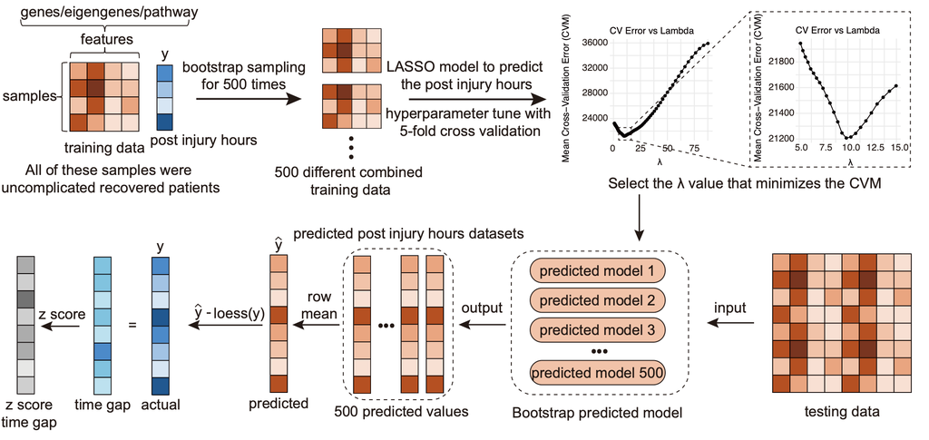

# 3. Installing `TempoGap`

```r
# devtools::install_github("DrCTD/TempoGap")
library(TempoGap)
library(tidyverse)
```

# 4. Example Data

`TempoGap` can analyze:

- bulk RNA-seq normalized counts
- gene array data
- other clinical indicators
- cytokine profiles

As an example, we used the `GlueGrant2` T-cell, PMN and Monocytes transcriptomic data to train the temporal gap model. The `GlueGrant2` contains samples collected at multiple time points after injury, providing a suitable temporal structure for model development. The sampling distribution of the `GlueGrant2` cohort includes the following time intervals since injury:

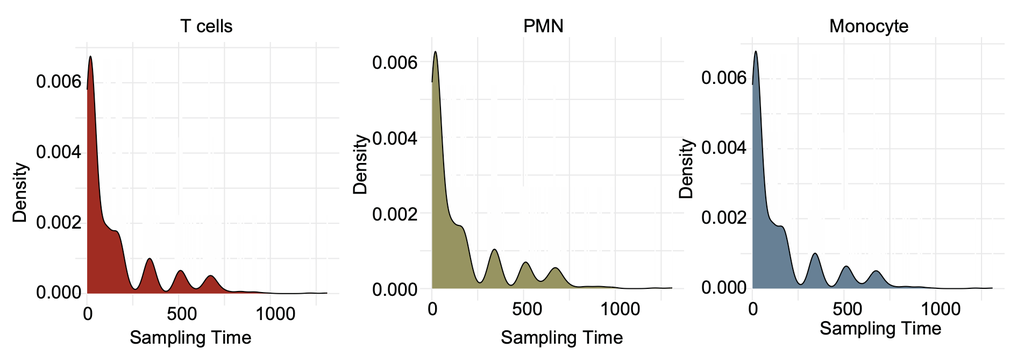

For this tutorial, we will use the T-cell subset from the GlueGrant2 dataset as an example. To begin, we load the T-cell data from GlueGrant2 into the R environment.

```r
meta <- read.csv(file = "../Result/20251119_tcell_metadata.csv")
expr <- read.csv(file = "../Result/20251119_tcell_expr.csv",
                 check.names = F,
                 row.names = 1)
```

check the T cell object information:

```r
str(meta)
```

```
## 'data.frame':    922 obs. of  32 variables:
##  $ Experiment.Names         : int  401283 401284 321460 321542 321543 321464 401339 401340 320348 320349 ...
##  $ Original.order           : int  182 330 2096 2237 2357 2462 1076 1622 2094 2353 ...
##  $ RECOVERY_CLASS           : chr  "Complicated" "Complicated" "Uncomplicated" "Uncomplicated" ...
##  $ MICROARRAY_ID            : int  18226751 29542962 31650682 21070665 22775117 13194569 13630755 19583298 5601004 21423372 ...
##  $ Extant.Microarray.DeID.  : chr  "yes" "yes" "yes" "yes" ...
##  $ PATIENT_ID               : chr  "10089333" "10089333" "10211506" "10211506" ...
##  $ HOURS_SINCE_INJURY       : num  6.8 26.6 7.3 29.9 103.1 ...
##  $ X0.1.4.7.14.21.28.days   : num  0.5 1 0.5 1 4 7 0.5 4 0.5 4 ...
##  $ ARRAY_SAMPLE_TYPE        : chr  "T-cell" "T-cell" "T-cell" "T-cell" ...
##  $ PMN.ARRAYS               : logi  NA NA NA NA NA NA ...
##  $ PMN.0.1.4.7.14.21.28.days: logi  NA NA NA NA NA NA ...
##  $ PMN.COMP.UNCOMP          : logi  NA NA NA NA NA NA ...
##  $ SAMPLE_STUDYSTART_DAYS   : int  0 1 0 1 4 7 0 1 0 1 ...
##  $ AGE                      : int  30 30 20 20 20 20 36 36 34 34 ...
```

[output cut: 18 more lines]

```r
dim(expr)
```

```
## [1] 14566   922
```

Check the data to make sure the `colnames` of `expr` is totally identical the `experiment names` of `meta`.

```r
table(colnames(expr) == meta$Experiment.Names)
```

```
##
## TRUE
##  922
```

## Step 1. extract the uncomplicated recovery patients as the baseline patients.

Subjects were stratified into three recovery trajectories: **uncomplicated recovery** (UCR; recovery < 5 days after injury), **intermediate recovery** (IR; 5 days ≤ recovery ≤ 14 days), and **complicated recovery** (CR; no recovery by day 28, recovery > 14 days, or death). Patients in the CR group were significantly older than those in the UCR group. Furthermore, the incidence of adverse outcomes, including ventilator-associated pneumonia and nosocomial infections, was markedly higher in the CR group. We will choose the uncomplicated recovery patients as the baseline of immune recovery model.

```r
idx_ucr <- meta$RECOVERY_CLASS == "Uncomplicated"
table(idx_ucr)
```

```
## idx_ucr
## FALSE  TRUE
##   690   232
```

```r
expression_matrix <- as.matrix(expr[, idx_ucr])
time_vector <- meta$HOURS_SINCE_INJURY[idx_ucr]
```

## Step 2. Training the immune recovery clock in uncomplicated recovery trauma patients.

After preparing all required data, we use the `train_temporal_model` function to train the immune recovery model for trauma patients. This function includes several parameters that can be adjusted based on the needs of your specific project.

- `cv_folds` represents number of folds for cross-validation.
- `alpha` represents elastic net mixing parameter. Default is 1 (LASSO). If alpha is a vector of continuous numbers, hyperparameter optimization of alpha will be performed based on the vector.
- `n_boot` represents bootstrapping numbers.

> Beyond trauma patients, the `TempoGap` framework can also be applied to other diseases that include longitudinal sampling. Any data set with multiple time points can be used to train disease-specific recovery trajectory models.

```r
train_model <- train_temporal_model(expression_matrix = expression_matrix,
                                    time_vector = time_vector,
                                    n_boot = 100,
                                    seed = 123)
```

[output not shown]

[output cut: 445 more lines]

[output not shown]

## Step 3. Temporal gap

After obtained the normal recovery trajectory of trauma patients, we will use the `predict_temporal_gap` to obtain temporal gap between immune recovery time and the actual time point since injury. The parameter of `predict_temporal_gap` includes:

- `model`: A trained `cv.glmnet` object return from `train_temporal_model` function.
- `expression_matrix`: A numeric matrix (features x samples) of gene/protein/lipid… expression values for prediction.
- `actual_time`: A numeric vector of actual post-injury hours (for computing TempoGap).
- `n_boot`: Bootstrapping numbers used in `train_temporal_gap` function

```r
# We need to remove the healthy contorls.
idx_control <- meta$RECOVERY_CLASS == "Control"
x_test <- expr[,!idx_control]
y_test <- meta$HOURS_SINCE_INJURY[!idx_control]
```

```r
# temporal gap
predicted_results <- predict_temporal_gap(model = train_model$model,
                                          expression_matrix = as.matrix(x_test),
                                          actual_time = y_test,
                                          n_boot = 100)
```

[output not shown]

[output cut: 85 more lines]

## Step 4. Visualization

We can use the `plot_bootstrap_coefficients` function to visualize the coefficient stability and contributions within our model:

[figure not shown]

```r
plot_bootstrap_coefficients(coef_matrix = train_model$coef_matrix,
                            top_n = 50)
```

We can use the `plot_temporal_gap_distribution` function to visualize the correlation between predicted time and actual time:

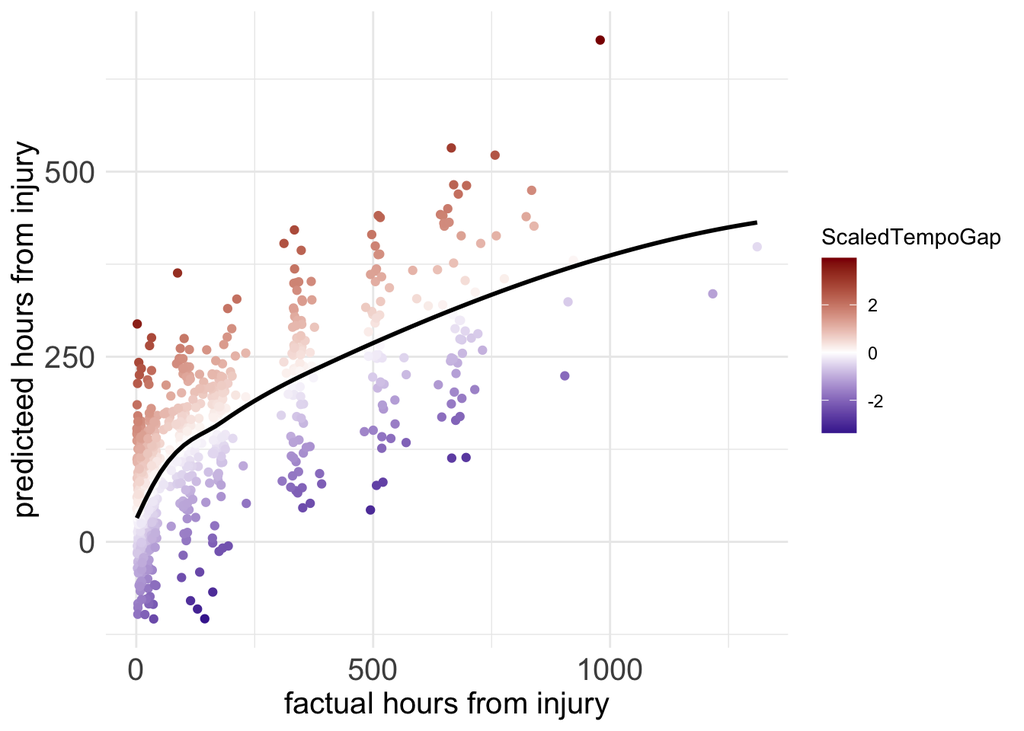

```r
plot_temporal_gap_distribution(gap_data = predicted_results$predicted_temporal_gap)
```

## Step 5. Cox hazard regression

If you would like to examine the association between the temporal gap and clinical indicators—such as recovery time or ICU discharge days. You can use the `cox_analysis_tempo_gap` function.

```r
event <- ifelse(meta$TIME_TO_RECOVERY > 30, 0, 1)[!idx_control]
time_to_event <- meta$TIME_TO_RECOVERY[!idx_control]
cox_results <- cox_analysis_tempo_gap(tempo_gap = predicted_results$predicted_temporal_gap$ScaledTempoGap,
                                      time_to_event = time_to_event,
                                      event = event,
                                      cut_method = "none")
cox_results$summary
```

```
## Call:
## coxph(formula = cox_formula, data = df)
##
##   n= 900, number of events= 815
##    (2 observations deleted due to missingness)
##
##              coef exp(coef) se(coef)     z Pr(>|z|)
## tempo_gap 0.24265   1.27462  0.03221 7.533 4.97e-14 ***
## ---
## Signif. codes:  0 '***' 0.001 '**' 0.01 '*' 0.05 '.' 0.1 ' ' 1
##
##           exp(coef) exp(-coef) lower .95 upper .95
## tempo_gap     1.275     0.7845     1.197     1.358
##
## Concordance= 0.588  (se = 0.011 )
## Likelihood ratio test= 55.96  on 1 df,   p=7e-14
## Wald test            = 56.74  on 1 df,   p=5e-14
## Score (logrank) test = 56.44  on 1 df,   p=6e-14
```